# HW 1 TASK 2

```r
#TASK 2

library(data.table)
require(data.table)
library(datasets)
require(datasets)
library(plyr)
require(plyr)


odds=read.csv("C:/Users/durda/Desktop/IE 582 HW/Datalar/bets.csv")
odds[,"1/Odds"]<- (1/odds$value)

matches=read.csv("C:/Users/durda/Desktop/IE 582 HW/Datalar/matches.csv")
EPLmatches=matches[matches$league_id=='148',]
EPLmatches<-EPLmatches[,c(3,9,10)]

EPLmatches<-data.table(EPLmatches)
odds<- data.table(odds)
setkey(EPLmatches,match_id)
setkey(odds,match_id)
odds<-merge(odds,EPLmatches)


BetOlimp=odds[odds$odd_bookmakers=='BetOlimp',]
Youwin=odds[odds$odd_bookmakers=="youwin",]
Expekt=odds[odds$odd_bookmakers=="Expekt",]
Sekabet=odds[odds$odd_bookmakers=="Sekabet",]


#For Betolimp

B_Drawodds=data.table(BetOlimp[BetOlimp$variable=="odd_x",])
B_Homeodds=data.table(BetOlimp[BetOlimp$variable=="odd_1",])
B_Awayodds=data.table(BetOlimp[BetOlimp$variable=="odd_2",])


setkey(B_Drawodds,match_id)
setkey(B_Homeodds,match_id)
setkey(B_Awayodds,match_id)

x<-merge(B_Homeodds,B_Awayodds)
x<-merge(x,B_Drawodds)
x<-x[,c(1,3,4,5,6,11,12,13,18,19,20,21,22)]
setnames(x, old= c("value.x","1/Odds.x","value.y","1/Odds.y","value","1/Odds"), new=c("odd_1","probHome","odd_2","probAway","odd_x","probDraw"))

x[,HomeNormalizedProb:=((x$probHome)/(x$probDraw+x$probHome+ x$probAway))]
x[,AwayNormalizedProb:=((x$probAway)/(x$probDraw+x$probHome+ x$probAway))]
x[,DrawNormalizedProb:=((x$probDraw)/(x$probDraw+x$probHome+ x$probAway))]

plot(x$HomeNormalizedProb-x$AwayNormalizedProb,x$DrawNormalizedProb,xlim = c(-1,1),ylim = c(0,1),main = 'Betolimp', xlab = 'HomeProb-AwayProb',ylab='DrawProb')

test<-x
test[,GoalsDifference:=test$match_hometeam_score-test$match_awayteam_score]

max(x$HomeNormalizedProb-x$AwayNormalizedProb)
```

```
## [1] 0.8308111
```

```r
min(x$HomeNormalizedProb-x$AwayNormalizedProb)
```

```
## [1] -0.8025375
```

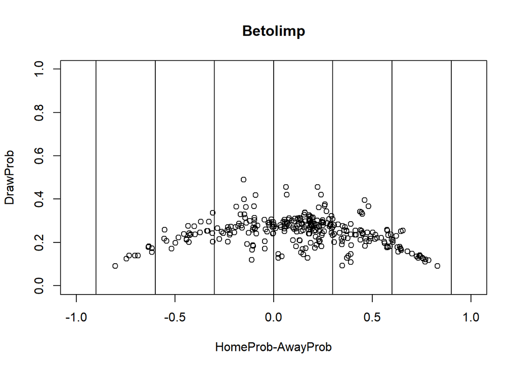

```r
abline(v=c(-0.9,-0.6,-0.3,0,0.3,0.6,0.9))
```

```r
#Intervals
#Range1
Range1<-test[(HomeNormalizedProb-AwayNormalizedProb)>=-0.9 & (HomeNormalizedProb-AwayNormalizedProb)<=-0.6]
Range1
```

```
##    match_id odd_epoch.x variable.x odd_1   probHome variable.y odd_2
## 1:   163725  1545854152      odd_1  9.25 0.10810811      odd_2  1.35
## 2:   164263  1546178340      odd_1 12.25 0.08163265      odd_2  1.24
## 3:   166017  1547272415      odd_1 10.50 0.09523810      odd_2  1.34
## 4:   178781  1492968288      odd_1  9.78 0.10224949      odd_2  1.25
## 5:   224478  1508559366      odd_1  8.00 0.12500000      odd_2  1.24
## 6:   224485  1508506953      odd_1 14.00 0.07142857      odd_2  1.14
## 7:   224490  1509111013      odd_1 14.00 0.07142857      odd_2  1.12
## 8:   224493  1509205168      odd_1 17.00 0.05882353      odd_2  1.06
## 9:   224494  1509205173      odd_1 10.50 0.09523810      odd_2  1.17
##     probAway variable odd_x  probDraw match_hometeam_score
## 1: 0.7407407    odd_x  5.62 0.1779359                    2
## 2: 0.8064516    odd_x  6.96 0.1436782                    1
## 3: 0.7462687    odd_x  5.37 0.1862197                    0
## 4: 0.8000000    odd_x  5.08 0.1968504                    1
```

[output cut: 25 more lines]

```r
Draw1<-Range1[GoalsDifference==0]


fraction<- length(Draw1$match_id)/length(Range1$match_id)
fraction
```

```
## [1] 0.3333333
```

```r
Draw1[,bias:=fraction-DrawNormalizedProb]
R1<-length(Draw1[bias>=0]$match_id)


#Range 2
Range2<-test[(HomeNormalizedProb-AwayNormalizedProb)>=-0.6 & (HomeNormalizedProb-AwayNormalizedProb)<=-0.3]


Draw2<-Range2[GoalsDifference==0]


fraction2<- length(Draw2$match_id)/length(Range2$match_id)
fraction2
```

```
## [1] 0.08333333
```

```r
Draw2[,bias:=fraction2-DrawNormalizedProb]
R2<-length(Draw2[bias>=0]$match_id)


#Range 3
Range3<-test[(HomeNormalizedProb-AwayNormalizedProb)>=-0.3 & (HomeNormalizedProb-AwayNormalizedProb)<=0]


Draw3<-Range3[GoalsDifference==0]


fraction3<- length(Draw3$match_id)/length(Range2)
fraction3
```

```
## [1] 0.4117647
```

```r
Draw3[,bias:=fraction3-DrawNormalizedProb]
R3<-length(Draw3[bias>=0]$match_id)

#Range 4
Range4<-test[(HomeNormalizedProb-AwayNormalizedProb)>=0 & (HomeNormalizedProb-AwayNormalizedProb)<=0.3]


Draw4<-Range4[GoalsDifference==0]


fraction4<- length(Draw4$match_id)/length(Range4$match_id)
fraction4
```

```
## [1] 0.1209677
```

```r
Draw4[,bias:=fraction4-DrawNormalizedProb]
R4<-length(Draw4[bias>=0]$match_id)


#Range 5
Range5<-test[(HomeNormalizedProb-AwayNormalizedProb)>=0.3 & (HomeNormalizedProb-AwayNormalizedProb)<=0.6]


Draw5<-Range5[GoalsDifference==0]


fraction5<- length(Draw5$match_id)/length(Range5)
fraction5
```

```
## [1] 0.9411765
```

```r
Draw5[,bias:=fraction5-DrawNormalizedProb]
R5<-length(Draw5[bias>=0]$match_id)

#Range 6
Range6<-test[(HomeNormalizedProb-AwayNormalizedProb)>=0.6 & (HomeNormalizedProb-AwayNormalizedProb)<=0.9]
Draw6<-Range6[GoalsDifference==0]

fraction6<- length(Draw6$match_id)/length(Range6)
fraction6
```

```
## [1] 0.05882353
```

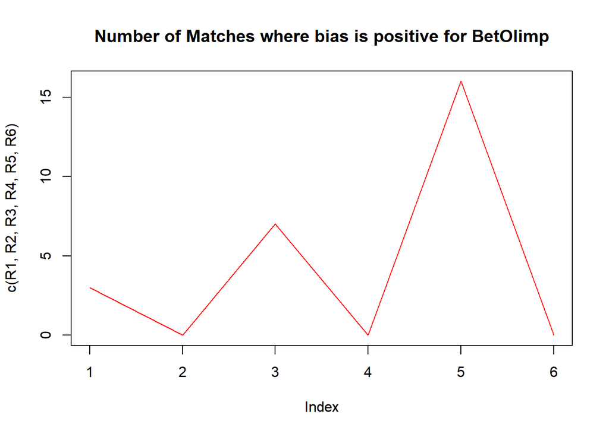

```r
Draw6[,bias:=fraction6-DrawNormalizedProb]
R6<-length(Draw6[bias>=0]$match_id)

plot(c(R1,R2,R3,R4,R5,R6),col='red',type='l',main = 'Number of Matches where bias is positive for BetOlimp')
```

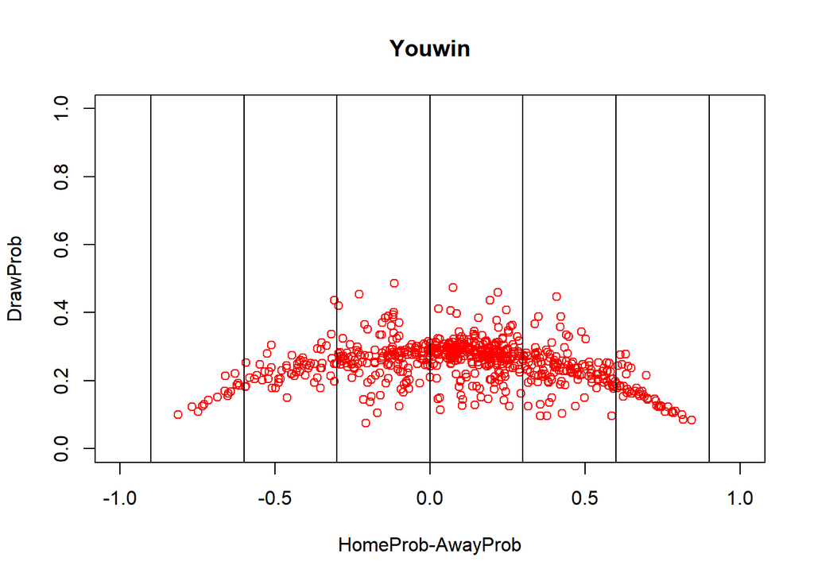

```r
##########################################################

#For Youwin

Y_Drawodds=data.table(Youwin[Youwin$variable=="odd_x",])
Y_Homeodds=data.table(Youwin[Youwin$variable=="odd_1",])
Y_Awayodds=data.table(Youwin[Youwin$variable=="odd_2",])


setkey(Y_Drawodds,match_id)
setkey(Y_Homeodds,match_id)
setkey(Y_Awayodds,match_id)

xY<-merge(Y_Homeodds,Y_Awayodds)
xY<-merge(xY,Y_Drawodds)
xY<-xY[,c(1,3,4,5,6,11,12,13,18,19,20,21,22)]



setnames(xY, old = c('value.x','1/Odds.x','value.y','1/Odds.y','value','1/Odds'), new = c('odd_1','probHome','odd_2','probAway','odd_x','probDraw'))

xY[,HomeNormalizedProb:=((xY$probHome)/(xY$probDraw+xY$probHome+ xY$probAway))]
xY[,AwayNormalizedProb:=((xY$probAway)/(xY$probDraw+xY$probHome+ xY$probAway))]
xY[,DrawNormalizedProb:=((xY$probDraw)/(xY$probDraw+xY$probHome+ xY$probAway))]


plot((xY$HomeNormalizedProb-xY$AwayNormalizedProb),xY$DrawNormalizedProb,xlim = c(-1,1),ylim = c(0,1),main = 'Youwin', xlab = 'HomeProb-AwayProb',ylab='DrawProb',col='red')
abline(v=c(-0.9,-0.6,-0.3,0,0.3,0.6,0.9))
```

```r
testY<-xY
testY[,GoalsDifference:=match_hometeam_score-match_awayteam_score]

#Intervals
#Range1
Range1Y<-testY[(HomeNormalizedProb-AwayNormalizedProb)>=-0.9 & (HomeNormalizedProb-AwayNormalizedProb)<=-0.6]
Range1Y
```

```
##     match_id odd_epoch.x variable.x odd_1   probHome variable.y odd_2
##  1:   164263  1546178340      odd_1 11.00 0.09090909      odd_2  1.18
##  2:   164263  1546178340      odd_1 11.00 0.09090909      odd_2  1.18
##  3:   166017  1547272415      odd_1  9.75 0.10256410      odd_2  1.30
##  4:   171047  1548774892      odd_1 13.00 0.07692308      odd_2  1.15
##  5:   173464  1549465402      odd_1  9.75 0.10256410      odd_2  1.25
##  6:   181346  1551416682      odd_1 13.00 0.07692308      odd_2  1.18
##  7:   199851  1554780184      odd_1 11.00 0.09090909      odd_2  1.25
##  8:   206167  1556043497      odd_1 17.00 0.05882353      odd_2  1.13
##  9:   208237  1556508615      odd_1  9.75 0.10256410      odd_2  1.29
## 10:   212421  1557199199      odd_1 21.00 0.04761905      odd_2  1.08
## 11:   224425  1565478766      odd_1  9.50 0.10526316      odd_2  1.20
## 12:   224445  1566792523      odd_1 13.00 0.07692308      odd_2  1.13
## 13:   224455  1566843427      odd_1  9.75 0.10256410      odd_2  1.25
## 14:   224469  1568332967      odd_1 13.00 0.07692308      odd_2  1.13
```

[output cut: 53 more lines]

```r
Draw1Y<-Range1Y[GoalsDifference==0]


fractionY<- length(Draw1Y$match_id)/length(Range1Y$match_id)
fractionY
```

```
## [1] 0
```

```r
Draw1Y[,bias:=fractionY-DrawNormalizedProb]
R1Y<-length(Draw1Y[bias>=0]$match_id)


#Range 2
Range2Y<-testY[(HomeNormalizedProb-AwayNormalizedProb)>=-0.6 & (HomeNormalizedProb-AwayNormalizedProb)<=-0.3]


Draw2Y<-Range2Y[GoalsDifference==0]


fraction2Y<- length(Draw2Y$match_id)/length(Range2Y$match_id)
fraction2Y
```

```
## [1] 0.1333333
```

```r
Draw2Y[,bias:=fraction2Y-DrawNormalizedProb]
R2Y<-length(Draw2Y[bias>=0]$match_id)


#Range 3
Range3Y<-testY[(HomeNormalizedProb-AwayNormalizedProb)>=-0.3 & (HomeNormalizedProb-AwayNormalizedProb)<=0]


Draw3Y<-Range3Y[GoalsDifference==0]


fraction3Y<- length(Draw3Y$match_id)/length(Range3Y$match_id)
fraction3Y
```

```
## [1] 0.2193548
```

```r
Draw3Y[,bias:=fraction3Y-DrawNormalizedProb]
R3Y<-length(Draw3Y[bias>=0]$match_id)

#Range 4
Range4Y<-testY[(HomeNormalizedProb-AwayNormalizedProb)>=0 & (HomeNormalizedProb-AwayNormalizedProb)<=0.3]


Draw4Y<-Range4Y[GoalsDifference==0]


fraction4Y<- length(Draw4Y$match_id)/length(Range4Y$match_id)
fraction4Y
```

```
## [1] 0.2448276
```

```r
Draw4Y[,bias:=fraction4Y-DrawNormalizedProb]
R4Y<-length(Draw4Y[bias>=0]$match_id)


#Range 5
Range5Y<-testY[(HomeNormalizedProb-AwayNormalizedProb)>=0.3 & (HomeNormalizedProb-AwayNormalizedProb)<=0.6]


Draw5Y<-Range5Y[GoalsDifference==0]


fraction5Y<- length(Draw5Y$match_id)/length(Range5Y$match_id)
fraction5Y
```

```
## [1] 0.2307692
```

```r
Draw5Y[,bias:=fraction5Y-DrawNormalizedProb]
R5Y<-length(Draw5Y[bias>=0]$match_id)

#Range 6
Range6Y<-test[(HomeNormalizedProb-AwayNormalizedProb)>=0.6 & (HomeNormalizedProb-AwayNormalizedProb)<=0.9]
Draw6Y<-Range6Y[GoalsDifference==0]

fraction6Y<- length(Draw6Y$match_id)/length(Range6Y$match_id)
fraction6Y
```

```
## [1] 0.04
```

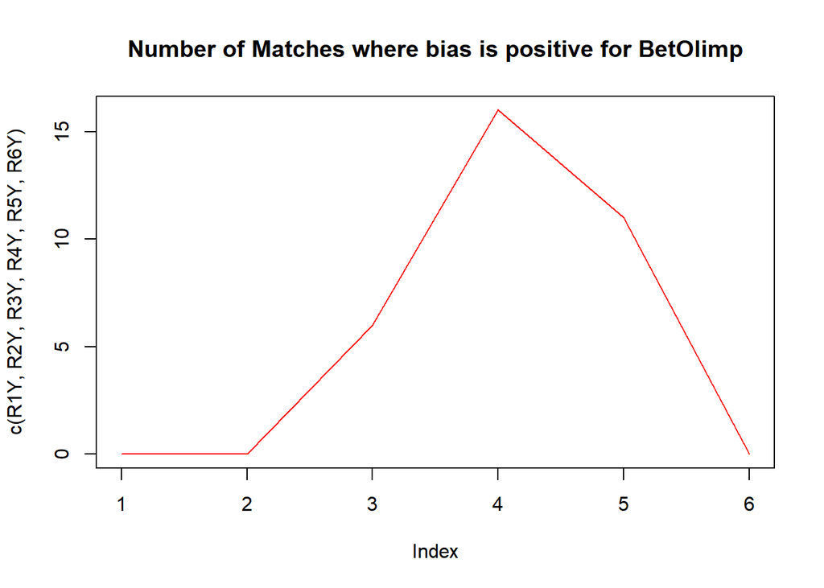

```r
Draw6Y[,bias:=fraction6Y-DrawNormalizedProb]
R6Y<-length(Draw6Y[bias>=0]$match_id)

plot(c(R1Y,R2Y,R3Y,R4Y,R5Y,R6Y),col='red',type='l',main = 'Number of Matches where bias is positive for BetOlimp')
```

```r
###########################################################

#FOR EXPEKT

E_Drawodds=data.table(Expekt[Expekt$variable=="odd_x",])
E_Homeodds=data.table(Expekt[Expekt$variable=="odd_1",])
E_Awayodds=data.table(Expekt[Expekt$variable=="odd_2",])


setkey(E_Drawodds,match_id)
setkey(E_Homeodds,match_id)
setkey(E_Awayodds,match_id)

xE<-merge(E_Homeodds,E_Awayodds)
xE<-merge(xE,E_Drawodds)
xE<-xE[,c(1,3,4,5,6,11,12,13,18,19,20)]

setnames(xE, old = c('value.x','1/Odds.x','value.y','1/Odds.y','value','1/Odds'), new = c('odd_1','probHome','odd_2','probAway','odd_x','probDraw'))

xE[,HomeNormalizedProb:=((xE$probHome)/(xE$probDraw+xE$probHome+ xE$probAway))]
xE[,AwayNormalizedProb:=((xE$probAway)/(xE$probDraw+xE$probHome+ xE$probAway))]
xE[,DrawNormalizedProb:=((xE$probDraw)/(xE$probDraw+xE$probHome+ xE$probAway))]

plot(xE$HomeNormalizedProb-xE$AwayNormalizedProb,xE$DrawNormalizedProb,xlim = c(-1,1),ylim = c(0,1),main = 'Expekt', xlab = 'HomeProb-AwayProb',ylab='DrawProb',col='blue')

setkey(EPLmatches,match_id)
setkey(xE,match_id)

testE<-merge(xE,EPLmatches)
length(testE$match_id)
```

```
## [1] 823
```

```r
testE[,GoalsDifference:=testE$match_hometeam_score-testE$match_awayteam_score]

max(xE$HomeNormalizedProb-xE$AwayNormalizedProb)
```

```
## [1] 0.8629431
```

```r
min(xE$HomeNormalizedProb-xE$AwayNormalizedProb)
```

```
## [1] -0.7965152
```

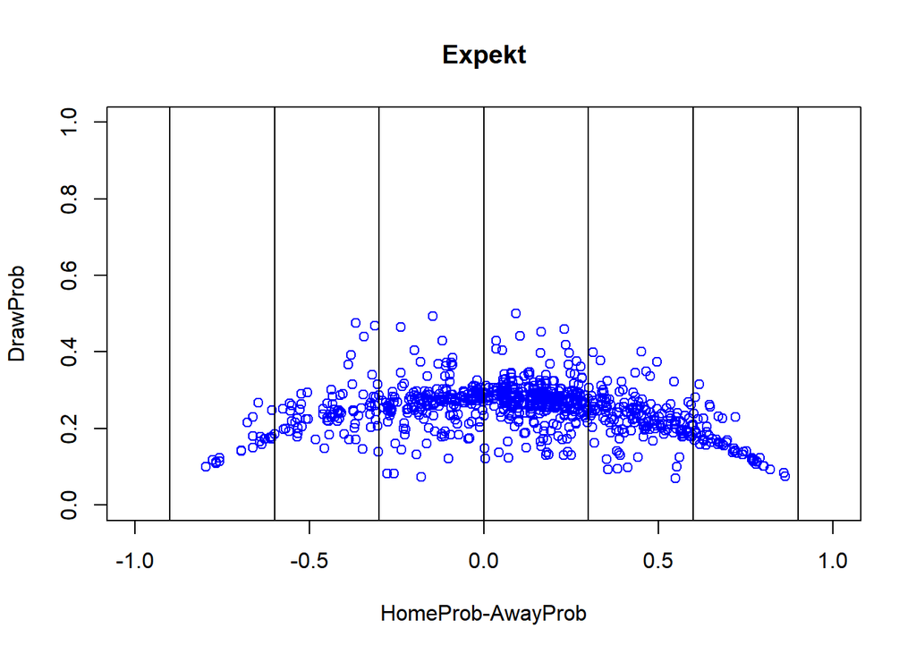

```r
abline(v=c(-0.9,-0.6,-0.3,0,0.3,0.6,0.9))
```

```r
#Intervals
#Range1
Range1E<-testE[(HomeNormalizedProb-AwayNormalizedProb)>=-0.9 & (HomeNormalizedProb-AwayNormalizedProb)<=-0.6]
Range1E
```

```
##     match_id odd_epoch.x variable.x odd_1   probHome variable.y odd_2
##  1:   163725  1545854152      odd_1  9.05 0.11049724      odd_2  1.33
##  2:   164263  1546178340      odd_1 11.75 0.08510638      odd_2  1.23
##  3:   166017  1547272415      odd_1 10.75 0.09302326      odd_2  1.34
##  4:   171047  1548774892      odd_1 16.50 0.06060606      odd_2  1.20
##  5:   173205  1549290850      odd_1  9.10 0.10989011      odd_2  1.37
##  6:   173464  1549465402      odd_1  9.60 0.10416667      odd_2  1.33
##  7:   178781  1492968288      odd_1 11.50 0.08695652      odd_2  1.22
##  8:   178781  1492968288      odd_1 11.50 0.08695652      odd_2  1.22
##  9:   181346  1551416682      odd_1 11.75 0.08510638      odd_2  1.24
## 10:   199851  1554780184      odd_1 10.25 0.09756098      odd_2  1.33
## 11:   206167  1556043497      odd_1 18.50 0.05405405      odd_2  1.18
## 12:   206167  1556043497      odd_1 18.50 0.05405405      odd_2  1.18
## 13:   208237  1556508615      odd_1  9.80 0.10204082      odd_2  1.35
## 14:   212421  1557199199      odd_1 19.00 0.05263158      odd_2  1.16
```

[output cut: 81 more lines]

```r
Draw1E<-Range1E[GoalsDifference==0]


fractionE<- length(Draw1E$match_id)/length(Range1E$match_id)
fraction
```

```
## [1] 0.3333333
```

```r
Draw1E[,bias:=fractionE-DrawNormalizedProb]
R1E<-length(Draw1E[bias>=0]$match_id)


#Range 2
Range2E<-testE[(HomeNormalizedProb-AwayNormalizedProb)>=-0.6 & (HomeNormalizedProb-AwayNormalizedProb)<=-0.3]


Draw2E<-Range2E[GoalsDifference==0]


fraction2E<- length(Draw2E$match_id)/length(Range2E$match_id)
fraction2
```

```
## [1] 0.08333333
```

```r
Draw2E[,bias:=fraction2E-DrawNormalizedProb]
R2E<-length(Draw2E[bias>=0]$match_id)


#Range 3
Range3E<-testE[(HomeNormalizedProb-AwayNormalizedProb)>=-0.3 & (HomeNormalizedProb-AwayNormalizedProb)<=0]


Draw3E<-Range3E[GoalsDifference==0]


fraction3E<- length(Draw3E$match_id)/length(Range3E$match_id)
fraction3E
```

```
## [1] 0.2458101
```

```r
Draw3E[,bias:=fraction3E-DrawNormalizedProb]
R3E<-length(Draw3E[bias>=0]$match_id)

#Range 4
Range4E<-testE[(HomeNormalizedProb-AwayNormalizedProb)>=0 & (HomeNormalizedProb-AwayNormalizedProb)<=0.3]


Draw4E<-Range4E[GoalsDifference==0]


fraction4E<- length(Draw4E$match_id)/length(Range4E$match_id)
fraction4E
```

```
## [1] 0.2568807
```

```r
Draw4E[,bias:=fraction4E-DrawNormalizedProb]
R4E<-length(Draw4E[bias>=0]$match_id)


#Range 5
Range5E<-testE[(HomeNormalizedProb-AwayNormalizedProb)>=0.3 & (HomeNormalizedProb-AwayNormalizedProb)<=0.6]


Draw5E<-Range5E[GoalsDifference==0]


fraction5E<- length(Draw5E$match_id)/length(Range5E$match_id)
fraction5E
```

```
## [1] 0.2111801
```

```r
Draw5E[,bias:=fraction5E-DrawNormalizedProb]
R5E<-length(Draw5E[bias>=0]$match_id)

#Range 6
Range6E<-test[(HomeNormalizedProb-AwayNormalizedProb)>=0.6 & (HomeNormalizedProb-AwayNormalizedProb)<=0.9]
Draw6E<-Range6E[GoalsDifference==0]

fraction6E<- length(Draw6E$match_id)/length(Range6E$match_id)
fraction6E
```

```
## [1] 0.04
```

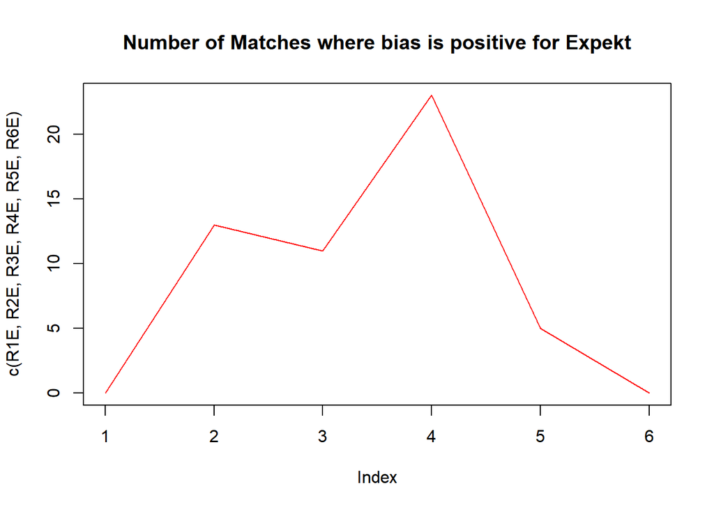

```r
Draw6E[,bias:=fraction6E-DrawNormalizedProb]
R6E<-length(Draw6E[bias>=0]$match_id)

plot(c(R1E,R2E,R3E,R4E,R5E,R6E),col='red',type='l',main = 'Number of Matches where bias is positive for Expekt')
```

```r
##########################################################################

# FOR SEKABET

S_Drawodds=data.table(Sekabet[Sekabet$variable=="odd_x",])
S_Homeodds=data.table(Sekabet[Sekabet$variable=="odd_1",])
S_Awayodds=data.table(Sekabet[Sekabet$variable=="odd_2",])


setkey(S_Drawodds,match_id)
setkey(S_Homeodds,match_id)
setkey(S_Awayodds,match_id)

xS<-merge(S_Homeodds,S_Awayodds)
xS<-merge(xS,S_Drawodds)
xS<-xS[,c(1,3,4,5,6,11,12,13,18,19,20)]

setnames(xS, old = c('value.x','1/Odds.x','value.y','1/Odds.y','value','1/Odds'), new = c('odd_1','probHome','odd_2','probAway','odd_x','probDraw'))

xS[,HomeNormalizedProb:=((xS$probHome)/(xS$probDraw+xS$probHome+ xS$probAway))]
xS[,AwayNormalizedProb:=((xS$probAway)/(xS$probDraw+xS$probHome+ xS$probAway))]
xS[,DrawNormalizedProb:=((xS$probDraw)/(xS$probDraw+xS$probHome+ xS$probAway))]

plot(xS$HomeNormalizedProb-xS$AwayNormalizedProb,xS$DrawNormalizedProb,xlim = c(-1,1),ylim = c(0,1),main = 'Sekabet', xlab = 'HomeProb-AwayProb',ylab='DrawProb',col='green')

setkey(EPLmatches,match_id)
setkey(xS,match_id)

testS<-merge(xS,EPLmatches)
length(testS$match_id)
```

```
## [1] 59
```

```r
testS[,GoalsDifference:=testS$match_hometeam_score-testS$match_awayteam_score]

max(xS$HomeNormalizedProb-xS$AwayNormalizedProb)
```

```
## [1] 0.7981242
```

```r
min(xS$HomeNormalizedProb-xS$AwayNormalizedProb)
```

```
## [1] -0.5786452
```

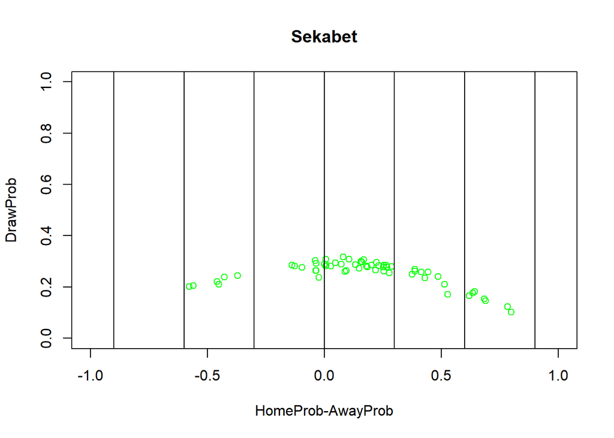

```r
abline(v=c(-0.9,-0.6,-0.3,0,0.3,0.6,0.9))
```

```r
#Intervals
#Range1
Range1S<-testS[(HomeNormalizedProb-AwayNormalizedProb)>=-0.9 & (HomeNormalizedProb-AwayNormalizedProb)<=-0.6]
Range1S
```

```
## Empty data.table (0 rows and 17 cols): match_id,odd_epoch.x,variable.x,odd_1,probHome,variable.y...
```

```r
Draw1S<-Range1S[GoalsDifference==0]


fractionS<- length(Draw1S$match_id)/length(Range1S$match_id)

Draw1S[,bias:=fractionS-DrawNormalizedProb]
R1S<-length(Draw1S[bias>=0]$match_id)


#Range 2
Range2S<-testS[(HomeNormalizedProb-AwayNormalizedProb)>=-0.6 & (HomeNormalizedProb-AwayNormalizedProb)<=-0.3]


Draw2S<-Range2S[GoalsDifference==0]


fraction2S<- length(Draw2S$match_id)/length(Range2S$match_id)
fraction2S
```

```
## [1] 0
```

```r
Draw2S[,bias:=fraction2S-DrawNormalizedProb]
R2S<-length(Draw2S[bias>=0]$match_id)


#Range 3
Range3S<-testS[(HomeNormalizedProb-AwayNormalizedProb)>=-0.3 & (HomeNormalizedProb-AwayNormalizedProb)<=0]


Draw3S<-Range3S[GoalsDifference==0]


fraction3S<- length(Draw3S$match_id)/length(Range3S$match_id)
fraction3S
```

```
## [1] 0
```

```r
Draw3S[,bias:=fraction3S-DrawNormalizedProb]
R3S<-length(Draw3S[bias>=0]$match_id)

#Range 4
Range4S<-testS[(HomeNormalizedProb-AwayNormalizedProb)>=0 & (HomeNormalizedProb-AwayNormalizedProb)<=0.3]


Draw4S<-Range4S[GoalsDifference==0]


fraction4S<- length(Draw4S$match_id)/length(Range4S$match_id)
fraction4S
```

```
## [1] 0.1034483
```

```r
Draw4S[,bias:=fraction4S-DrawNormalizedProb]
R4S<-length(Draw4S[bias>=0]$match_id)


#Range 5
Range5S<-testS[(HomeNormalizedProb-AwayNormalizedProb)>=0.3 & (HomeNormalizedProb-AwayNormalizedProb)<=0.6]


Draw5S<-Range5S[GoalsDifference==0]


fraction5S<- length(Draw5S$match_id)/length(Range5S$match_id)
fraction5S
```

```
## [1] 0.2222222
```

```r
Draw5S[,bias:=fraction5S-DrawNormalizedProb]
R5S<-length(Draw5S[bias>=0]$match_id)

#Range 6
Range6S<-test[(HomeNormalizedProb-AwayNormalizedProb)>=0.6 & (HomeNormalizedProb-AwayNormalizedProb)<=0.9]
Draw6S<-Range6S[GoalsDifference==0]

fraction6S<- length(Draw6S$match_id)/length(Range6S$match_id)
fraction6S
```

```
## [1] 0.04
```

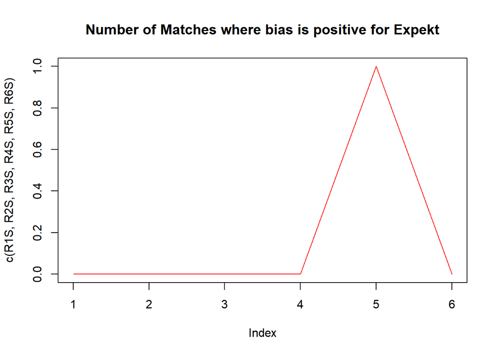

```r
Draw6S[,bias:=fraction6S-DrawNormalizedProb]
R6S<-length(Draw6S[bias>=0]$match_id)

plot(c(R1S,R2S,R3S,R4S,R5S,R6S),col='red',type='l',main = 'Number of Matches where bias is positive for Expekt')
```

```r
Compare<-c(R1+R2+R3+R4+R5+R6,R1Y+R2Y+R3Y+R4Y+R5Y+R6Y,R1E+R2E+R3E+R4E+R5E+R6E,R1S+R2S+R3S+R4S+R5S+R6S)
Compare
```

```
## [1] 26 33 52  1
```

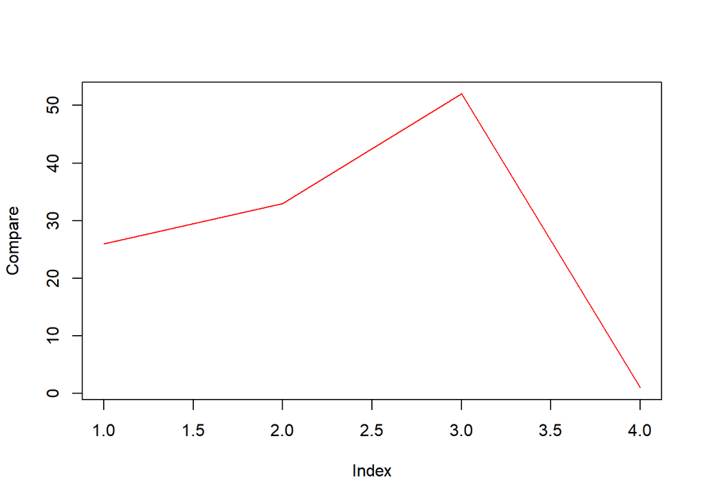

```r
plot(Compare,type = 'l',col='red')
```

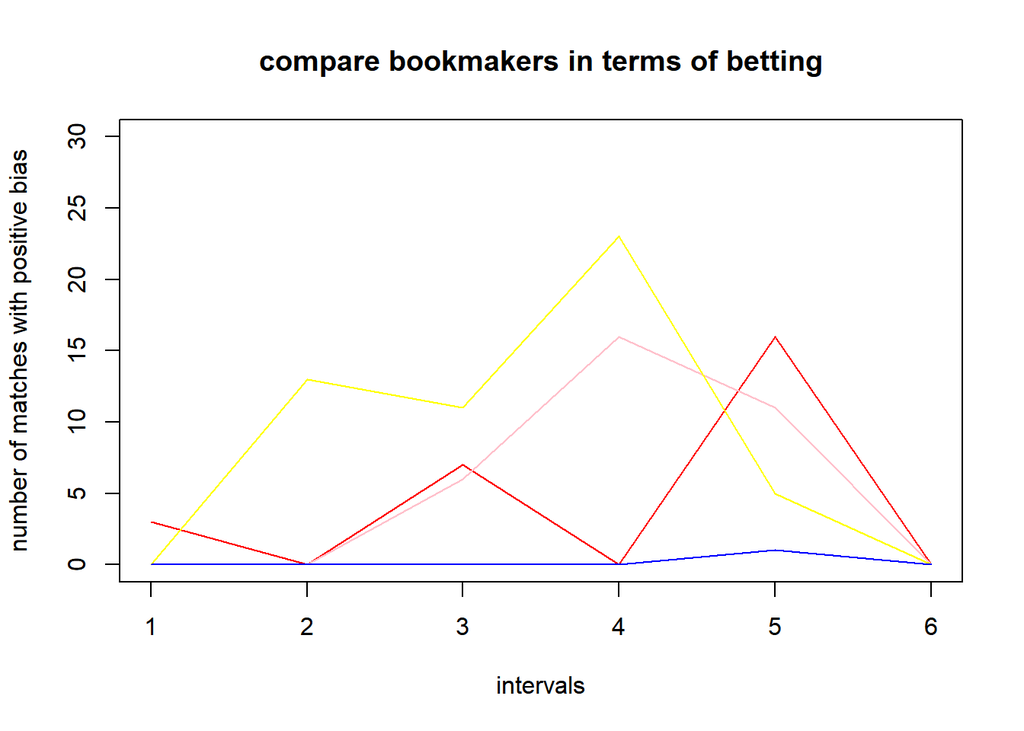

```r
v<-c(R1Y,R2Y,R3Y,R4Y,R5Y,R6Y)
y<-c(R1E,R2E,R3E,R4E,R5E,R6E)
z<-c(R1S,R2S,R3S,R4S,R5S,R6S)
plot(c(R1,R2,R3,R4,R5,R6),col='red',type='l',ylim = c(0,30),main = "compare bookmakers in terms of betting",xlab = "intervals",ylab = "number of matches with positive bias")
lines(v,col='pink',type='l')
lines(y,col='yellow',type='l')
lines(z,col='blue',type='l')
```

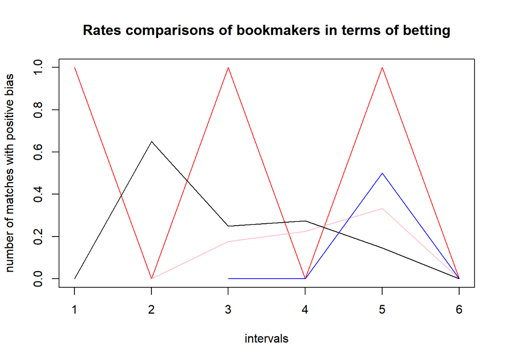

```r
B<-c((R1/length(Draw1$match_id)),(R2/length(Draw2$match_id)),(R3/length(Draw3$match_id)),(R4/length(Draw4$match_id)),(R5/length(Draw5$match_id)),(R6/length(Draw6$match_id)))
Y<-c((R1Y/length(Draw1Y$match_id)),(R2Y/length(Draw2Y$match_id)),(R3Y/length(Draw3Y$match_id)),(R4Y/length(Draw4Y$match_id)),(R5Y/length(Draw5Y$match_id)),(R6Y/length(Draw6Y$match_id)))
E<-c((R1E/length(Draw1E$match_id)),(R2E/length(Draw2E$match_id)),(R3E/length(Draw3E$match_id)),(R4E/length(Draw4E$match_id)),(R5E/length(Draw5E$match_id)),(R6E/length(Draw6E$match_id)))
S<-c((R1S/length(Draw1S$match_id)),(R2S/length(Draw2S$match_id)),(R3S/length(Draw3$match_id)),(R4S/length(Draw4$match_id)),(R5S/length(Draw5S$match_id)),(R6S/length(Draw6$match_id)))

plot(B,col='red',type='l',ylim = c(0,1),main = "Rates comparisons of bookmakers in terms of betting",xlab = "intervals",ylab = "number of matches with positive bias")
lines(Y,col='pink',type='l')
lines(E,type='l')
lines(S,col='blue',type='l')
```

##Comments

Initially i started with uploading data files into R and for this task i used matches, odds data which were given to us. By making changes into this data table i was intended to reach solutions of the questions.For each betting company, i seperated data and perform some analysis on data for each betting company within intervals. The different lines in the last graph shows number of games at which a better potentially make money in the long run because their fractions are greater than proposed draw probabilities

> > Second graph from the last showed that there is a tendency toward 3+4+5 th intervals which are (from -0.3 to 0.6 in total) for all bookmakers therefore it may be beneficial to recommend odds

> > last graph reveals the rates of[(bias >0 games)/(matches results in draw in that interval) ]for each intervals and each bookmaker. By making interpretation, Betolimp made the best recommends within the other bookamkers

> > One drawback is Sekabet includes less data compared with others.